# Chapter03

```r
library(tidyverse)
```

## 3. “Data visualisation” [Chapter 1 hardcopy]

### 3.2.4 Exercises

Q1. Run ggplot(data = mpg). What do you see?

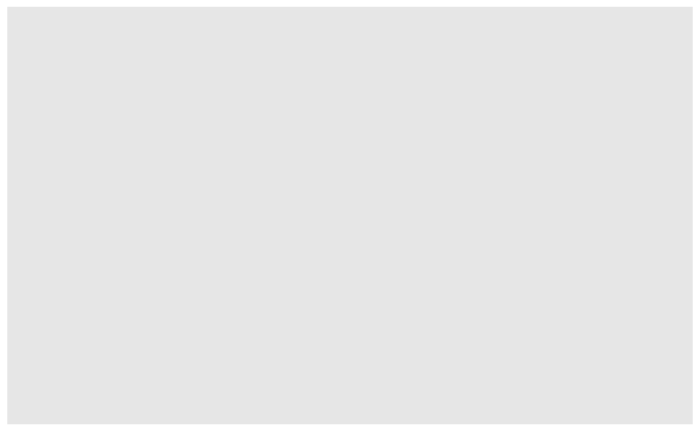

```r
ggplot(data = mpg)
```

A1. Grey background. No axes or data visible

Q2. How many rows are in mpg? How many columns?

```r
mpg
```

| manufacturer | model | displ | year | cyl | trans | drv | cty | hwy | fl | class |
| --- | --- | --- | --- | --- | --- | --- | --- | --- | --- | --- |
| audi | a4 | 1.8 | 1999 | 4 | auto(l5) | f | 18 | 29 | p | compact |
| audi | a4 | 1.8 | 1999 | 4 | manual(m5) | f | 21 | 29 | p | compact |
| audi | a4 | 2.0 | 2008 | 4 | manual(m6) | f | 20 | 31 | p | compact |
| audi | a4 | 2.0 | 2008 | 4 | auto(av) | f | 21 | 30 | p | compact |
| audi | a4 | 2.8 | 1999 | 6 | auto(l5) | f | 16 | 26 | p | compact |
| audi | a4 | 2.8 | 1999 | 6 | manual(m5) | f | 18 | 26 | p | compact |
| audi | a4 | 3.1 | 2008 | 6 | auto(av) | f | 18 | 27 | p | compact |
| audi | a4 quattro | 1.8 | 1999 | 4 | manual(m5) | 4 | 18 | 26 | p | compact |
| audi | a4 quattro | 1.8 | 1999 | 4 | auto(l5) | 4 | 16 | 25 | p | compact |
| audi | a4 quattro | 2.0 | 2008 | 4 | manual(m6) | 4 | 20 | 28 | p | compact |

[output cut: 224 more lines]

A2. 234 rows x 11 columns

Q3. What does the drv variable describe? Read the help for ?mpg to find out

```r
?mpg
```

A3. f = front-wheel drive, r = rear wheel drive, 4 = 4wd

Q4. Make a scatterplot of hwy vs cyl […y v’s x] A4.

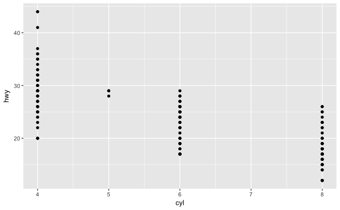

```r
ggplot(data = mpg) +
  geom_point(mapping = aes(x = cyl, y = hwy))
```

Q5. What happens if you make a scatterplot of class vs drv? Why is the plot not useful?

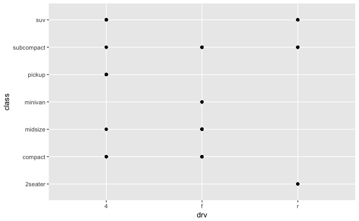

```r
ggplot(data = mpg) +
  geom_point(mapping = aes(x = drv, y = class))
```

A5. The plot has 2 categorical variables, (but shows no dependency), with an unknown number of points at many intersections (ie. overlap)

## 3. “Data visualisation” [Chapter 1 hardcopy]

### 3.3.1 Exercises

Q1. What’s gone wrong with this code? Why are the points not blue?

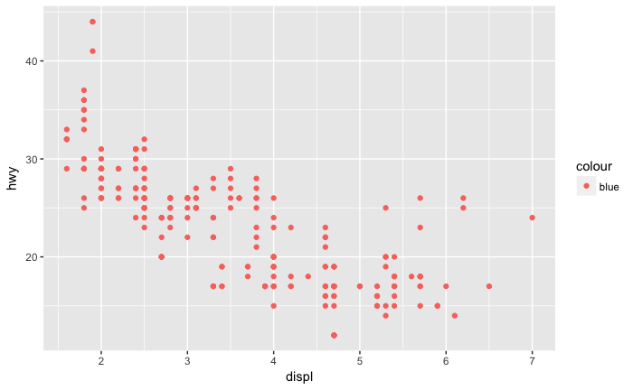

```r
ggplot(data = mpg) +
  geom_point(mapping = aes(x = displ, y = hwy, color = "blue"))
```

A1. Needs to be outside the aes() to work like that. (Inside, it just creates a ‘True’ condition, but with no say over what colour represents it in the plot)

Q2. Which variables in mpg are categorical? Which variables are continuous? How can you see this information when you run mpg?

```r
?mpg
mpg
```

| manufacturer | model | displ | year | cyl | trans | drv | cty | hwy | fl | class |
| --- | --- | --- | --- | --- | --- | --- | --- | --- | --- | --- |
| audi | a4 | 1.8 | 1999 | 4 | auto(l5) | f | 18 | 29 | p | compact |
| audi | a4 | 1.8 | 1999 | 4 | manual(m5) | f | 21 | 29 | p | compact |
| audi | a4 | 2.0 | 2008 | 4 | manual(m6) | f | 20 | 31 | p | compact |
| audi | a4 | 2.0 | 2008 | 4 | auto(av) | f | 21 | 30 | p | compact |
| audi | a4 | 2.8 | 1999 | 6 | auto(l5) | f | 16 | 26 | p | compact |
| audi | a4 | 2.8 | 1999 | 6 | manual(m5) | f | 18 | 26 | p | compact |
| audi | a4 | 3.1 | 2008 | 6 | auto(av) | f | 18 | 27 | p | compact |
| audi | a4 quattro | 1.8 | 1999 | 4 | manual(m5) | 4 | 18 | 26 | p | compact |
| audi | a4 quattro | 1.8 | 1999 | 4 | auto(l5) | 4 | 16 | 25 | p | compact |
| audi | a4 quattro | 2.0 | 2008 | 4 | manual(m6) | 4 | 20 | 28 | p | compact |

[output cut: 224 more lines]

A2. Categorical : : manufacturer; model; trans; drv; fl; class …6 Continuous : or : displ; year; cyl; cty; hwy …5

Q3. Map a continuous variable to color, size, and shape. [I initially misunderstood the requirement, and mapped them all in one plot] How do these aesthetics behave differently for categorical vs. continuous variables?

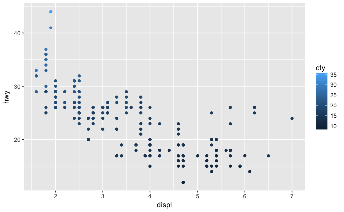

```r
ggplot(data = mpg) + geom_point(mapping = aes(x = displ, y = hwy, color = cty))
```

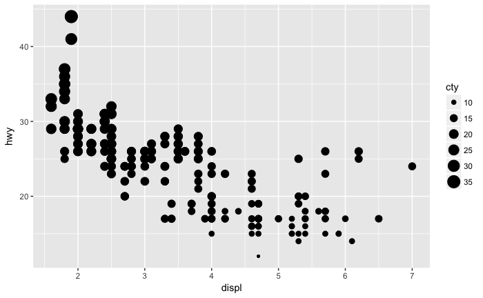

```r
ggplot(data = mpg) + geom_point(mapping = aes(x = displ, y = hwy, size = cty))
```

`ggplot(data = mpg) + geom_point(mapping = aes(x = displ, y = hwy, shape = cty))` # “Error: A continuous variable cannot be mapped to shape”"

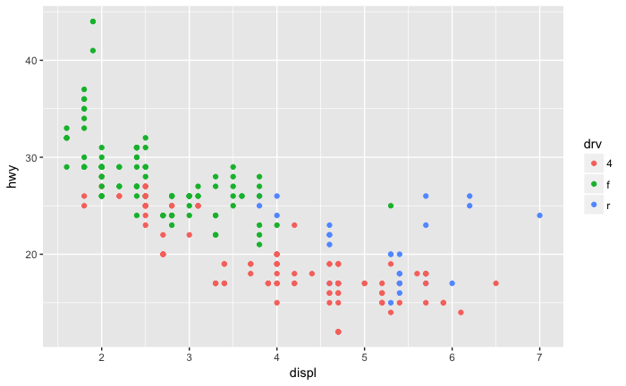

```r
ggplot(data = mpg) + geom_point(mapping = aes(x = displ, y = hwy, color = drv))
```

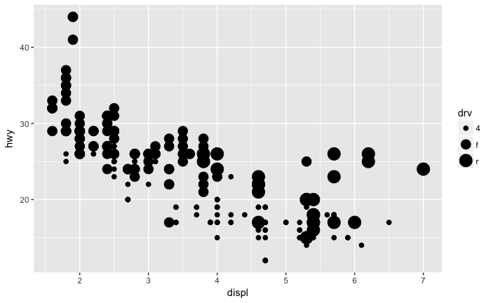

```r
ggplot(data = mpg) + geom_point(mapping = aes(x = displ, y = hwy, size = drv))
```

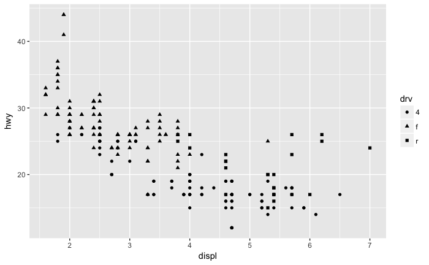

```r
ggplot(data = mpg) + geom_point(mapping = aes(x = displ, y = hwy, shape = drv))
```

A3. color : different hues v’s tints & shades of a single hue size : allocation of size to variable is arbitrary (warning) v’s relates to size of variable shape : allocation of shape to variable is arbitrary v’s error (as ‘meaningless’)

Q4. What happens if you map the same variable to multiple aesthetics?

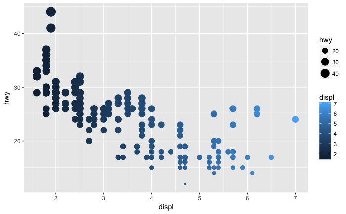

```r
ggplot(data = mpg) +
  geom_point(mapping = aes(x = displ, y = hwy, color = displ, size = hwy))
```

A4. The plot uses all the aesthetics. But there is redundancy, which can also be confusing (as a reader expects that an aesthetic is added for extra insight)

Q5. What does the stroke aesthetic do? What shapes does it work with?

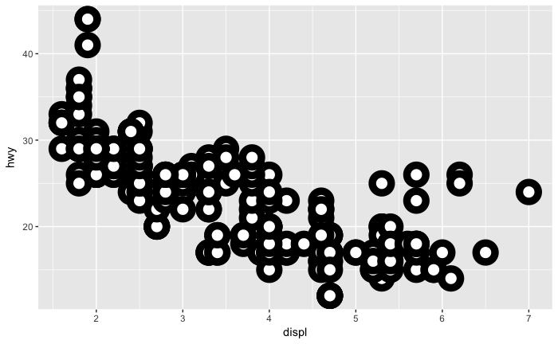

```r
?geom_point
ggplot(data = mpg) +
  geom_point(mapping = aes(x = displ, y = hwy), shape = 21, colour = "black", fill = "white", size = 5, stroke = 5)
```

A5. “For shapes that have a border (like 21), you can colour the inside and outside separately. Use the stroke aesthetic to modify the width of the border”

Q6. What happens if you map an aesthetic to something other than a variable name, like aes(colour = displ < 5) ?

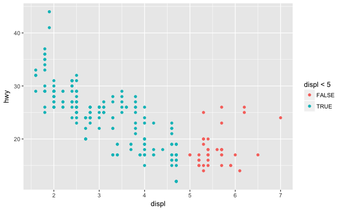

```r
ggplot(data = mpg) +
  geom_point(mapping = aes(x = displ, y = hwy, color = displ < 5))
```

A6. Expression is True/False for each point, splitting ‘displ’ into 2 sets with different colours

## 3. “Data visualisation” [Chapter 1 hardcopy]

### 3.5.1 Exercises

Q1. What happens if you facet on a continuous variable?

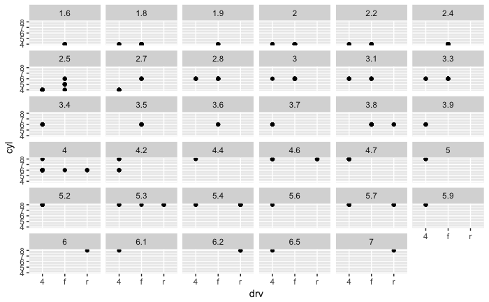

```r
ggplot(data = mpg) +
  geom_point(mapping = aes(x = drv, y = cyl)) +
  facet_wrap(~ displ)
```

A1. A cell is created for every value of the continuous variable. (Unlikely to be the most insightful choice)

Q2. What do the empty cells in plot with facet_grid(drv ~ cyl) mean? How do they relate to this plot?

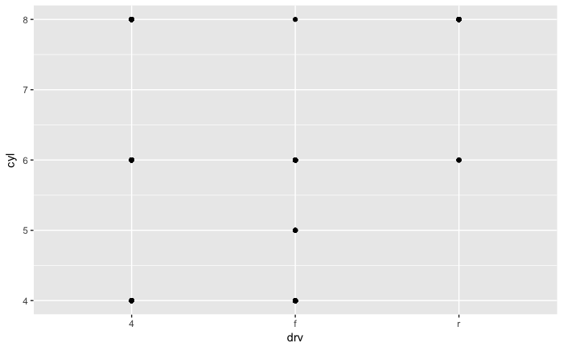

```r
ggplot(data = mpg) +
  geom_point(mapping = aes(x = drv, y = cyl))
```

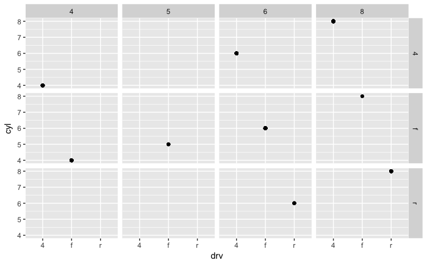

```r
ggplot(data = mpg) +
  geom_point(mapping = aes(x = drv, y = cyl)) +
  facet_grid(drv ~ cyl)
```

A2. 1st plot maps combinations of 2 categorical variables. No point at an intersection means the data doesn’t contain that combination 2nd plot has an empty cell when ‘the data doesn’t contain that combination’

Q3. What plots does the following code make? What does . do?

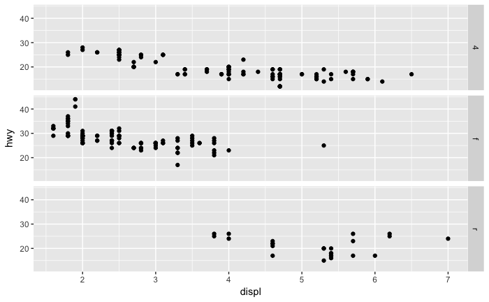

```r
ggplot(data = mpg) +
  geom_point(mapping = aes(x = displ, y = hwy)) +
  facet_grid(drv ~ .)
```

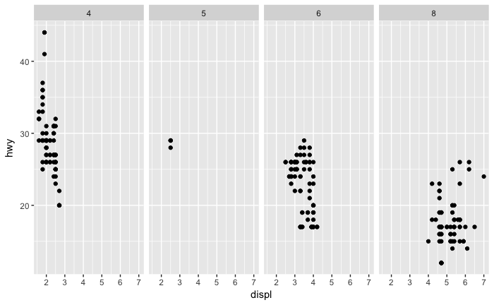

```r
ggplot(data = mpg) +
  geom_point(mapping = aes(x = displ, y = hwy)) +
  facet_grid(. ~ cyl)
```

A3. 1st plot has long horizontal cells (3 rows, no cols) 2nd plot has tall vertical cells (0 rows, 4 cols) . acts as a placeholder in the script (when facet_grid is missing a variable), and causes no faceting in that dimension

Q4. Take the first faceted plot in this section. What are the advantages to using faceting instead of the colour aesthetic? What are the disadvantages? How might the balance change if you had a larger dataset?

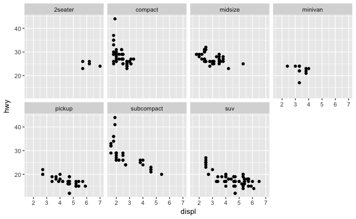

```r
ggplot(data = mpg) +
  geom_point(mapping = aes(x = displ, y = hwy)) +
  facet_wrap(~ class, nrow = 2)
```

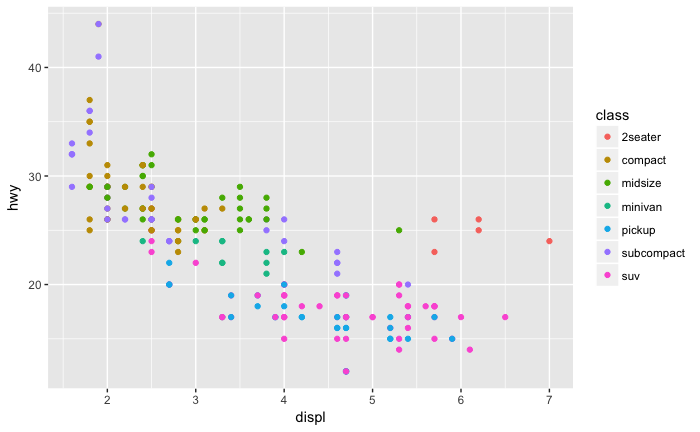

```r
ggplot(data = mpg) +
  geom_point(mapping = aes(x = displ, y = hwy, colour = class))
```

A4. Adv : reduces qty of points in a cell, so less overlapping and easier to spot different trends Disadv : harder to judge location of points in a cell relative to other cells (ie. overall picture). Squeezes the size of a cell Larger dataset has more overlapping, unless faceting used. (Though if the categorical variables used for faceting have many values, the cells will be tiny)

Q5. Read ?facet_wrap. What does nrow do? What does ncol do? What other options control the layout of the individual panels? Why doesn’t facet_grid() have nrow and ncol argument?

```r
?facet_wrap
```

A5. facet_wrap wraps a 1d sequence of panels into 2d. This is generally a better use of screen space than facet_grid because most displays are roughly rectangular nrow breaks a single row of cells into the specified number of rows. Similarly ncol specifies number of cols to have in the plot as.table [= TRUE or FALSE] determines the starting facet to begin filling the plot. And dir [= “h” or “v”] determines the starting direction for filling in the plot facet_grid() has its x and y dimensions determined by its arguments (number of unique values of the 2 variables)

Q6. When using facet_grid() you should usually put the variable with more unique levels in the columns. Why? A6. PC displays are usually landscape format, so a reader can distinguish many columns more easily than many rows (and dependent variable is usually y-axis)

## 3. “Data visualisation” [Chapter 1 hardcopy]

### 3.6.1 Exercises

Q1. What geom would you use to draw a line chart? A boxplot? A histogram? An area chart? A1. geom_line(), geom_boxplot(), geom_histogram(), geom_area()

Q2. Run this code in your head and predict what the output will look like. Then, run the code in R and check your predictions

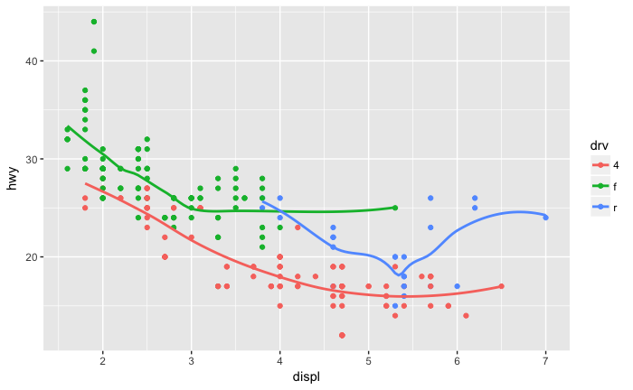

```r
ggplot(data = mpg, mapping = aes(x = displ, y = hwy, color = drv)) +
  geom_point() +
  geom_smooth(se = FALSE)
```

Q3. What does show.legend = FALSE do? What happens if you remove it? Why do you think I used it earlier in the chapter?

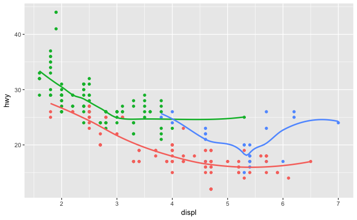

```r
ggplot(data = mpg, mapping = aes(x = displ, y = hwy, color = drv)) +
  geom_point(show.legend = FALSE) +
  geom_smooth(show.legend = FALSE, se = FALSE)
```

A3. Plot does not have a legend. Removing ‘FALSE’ will add a legend (because default is ‘TRUE’) ‘FALSE’ used earlier, to ‘expand’ the size of the plot used by data

Q4.What does the se argument to geom_smooth() do?

```r
?geom_smooth
```

A4. “display confidence interval around smooth? (TRUE by default, see level to control” …ie. adds error bands to a line

Q5. Will these two graphs look different? Why/why not?

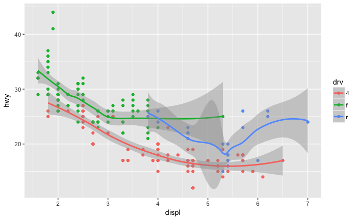

```r
ggplot(data = mpg, mapping = aes(x = displ, y = hwy, color = drv)) +
  geom_point() +
  geom_smooth()
```

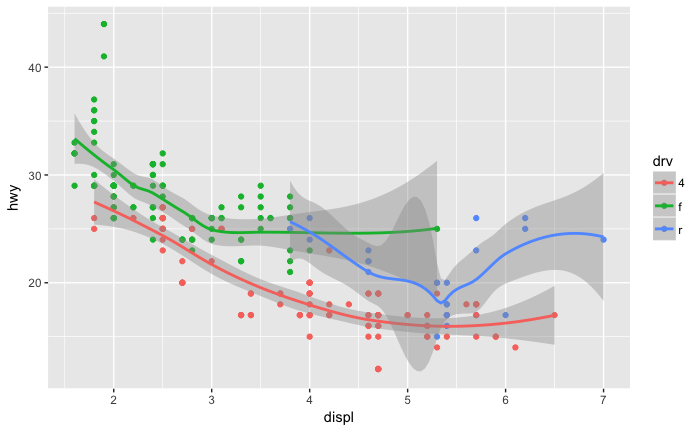

```r
ggplot() +
  geom_point(data = mpg, mapping = aes(x = displ, y = hwy, color = drv)) +
  geom_smooth(data = mpg, mapping = aes(x = displ, y = hwy, color = drv))
```

A5. They will look the same, because the data & mapping settings are the same in each. (The settings cascade down …ie. are inherited, but are superceded by local settings)

Q6. Recreate the R code necessary to generate the following graphs A6.1

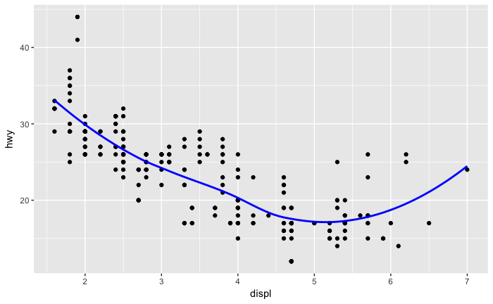

```r
ggplot(data = mpg, mapping = aes(x = displ, y = hwy)) +
  geom_point() +
  geom_smooth(color = "blue", se = FALSE)
```

A6.2

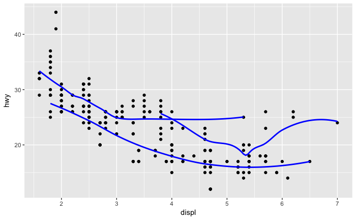

```r
ggplot(data = mpg, mapping = aes(x = displ, y = hwy)) +
  geom_point() +
  geom_smooth(mapping = aes(group = drv), color = "blue", se = FALSE)
```

A6.3

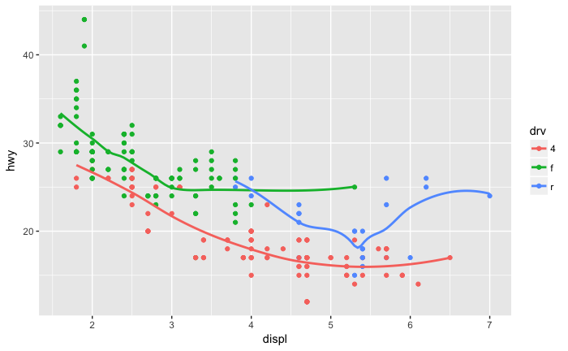

```r
ggplot(data = mpg, mapping = aes(x = displ, y = hwy, color = drv)) +
  geom_point() +
  geom_smooth(se = FALSE)
```

A6.4

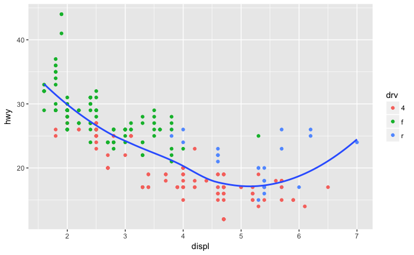

```r
ggplot(data = mpg, mapping = aes(x = displ, y = hwy)) +
  geom_point(mapping = aes(color = drv)) +
  geom_smooth(se = FALSE)
```

A6.5

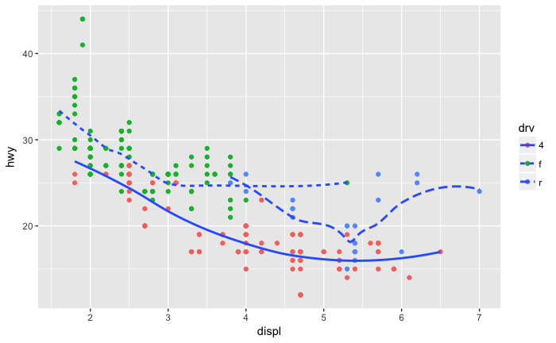

```r
ggplot(data = mpg, mapping = aes(x = displ, y = hwy)) +
  geom_point(mapping = aes(color = drv)) +
  geom_smooth(mapping = aes(linetype = drv), se = FALSE)
```

A6.6

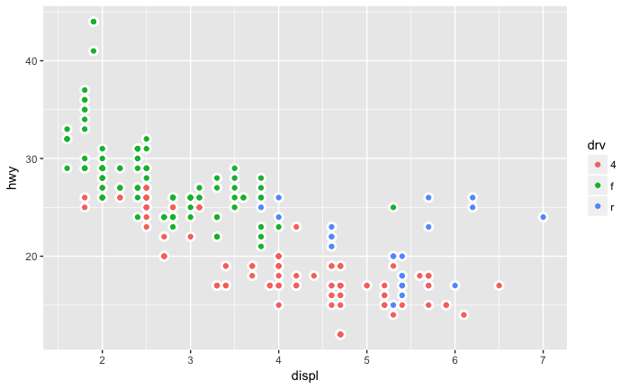

```r
ggplot(data = mpg, mapping = aes(x = displ, y = hwy)) +
  geom_point(color = "white", stroke = 2) +
  geom_point(mapping = aes(color = drv))
```

A6.6 Note the white points are in the earlier layer, with the colours then on top A6.6 Instead of ‘stroke=2’ could have used ‘size=4’ (from seeing someone else’s answer) A6.6 Actually, why did ‘stroke’ work? - does it not need to be with a shapetype that can have color+fill?